# SWAG_耗鑽率在直播推出前後差異

## 利用T-test檢測是否在直播推出前後，每日耗鑽是否有差異

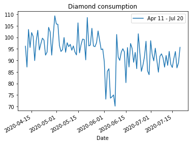

```python
import pandas as pd
import matplotlib.pyplot as plt
import numpy as np
import scipy.stats
with open('./diamond_consumption.csv', 'r') as df:
    df = pd.read_csv(df,  header=0, index_col=0, parse_dates=True, squeeze=True).drop(['Formula'], axis=1)
    df = df.rename(columns= {'Apr 11 - Jul 21':'diamond consumption(%)'})
    df = df.drop(pd.Timestamp('2020-04-29'))

df.plot(title='Diamond consumption')
plt.show()
```

#### 肉眼觀察看起來的確有稍微低一些，接著看經過T-test的結果

### 假設檢定

$H_0 : \mu_{before} = \mu_{after}$  
$H_1 : \mu_{before} \neq \mu_{after}$

```python
def t_test(group1, group2):
    mean1 = np.mean(group1)
    mean2 = np.mean(group2)
    std1 = np.std(group1)
    std2 = np.std(group2)
    nobs1 = len(group1)
    nobs2 = len(group2)

    modified_std1 = np.sqrt(np.float32(nobs1)/
                    np.float32(nobs1-1)) * std1
    modified_std2 = np.sqrt(np.float32(nobs2)/
                    np.float32(nobs2-1)) * std2
    (statistic, pvalue) = scipy.stats.ttest_ind_from_stats(
               mean1=mean1, std1=modified_std1, nobs1=nobs1,
               mean2=mean2, std2=modified_std2, nobs2=nobs2 )
    return statistic, pvalue
```

## T-test

### Compares two averages

或是Student's T Test，T-test用來比較兩個平均數是否不同，並能檢測兩組數據不同的顯著程度

### Why T-test ?

想觀測每日耗費鑽石的數量，利用肉眼觀察可以感覺到有略為下滑，但是較難直接判定兩者有相差，或是有多大的差異，利用T-test可以幫助我們利用統計的方法來評論數據

### How to do in this case ?

Student's T Test適合用來檢測兩個平均值的差異，我抓取直播推出（2020/6/1）前後50天（2020/4/11-5/30 & 2020/6/1-7/20)個別的平均來檢測，觀察在直播推出前後的差異

```python
before = df.head(50)
after = df.tail(50)

statistic, pvalue = t_test(before, after)
print(f'T-value : {statistic.item()}')
print(f'P-value : {pvalue}')
```

```
T-value : 7.062840418221451
P-value : [2.38245076e-10]
```

### 1. 先抓取前後各50天

### 2.接著經過T-test的結果

可以看到T-value是7.06，P-value則是2.38 * e-10（非常小）

### 3. T-value所代表的意義

T-value所代表的意義是兩個數據的差異是自己數據內的幾倍（Ratio between the difference between two groups and the difference within the groups.） 也就是說T值越大，兩數據的差異越大，T值越小則差異越小。 T值越接近0，兩組資料月沒有差異，在這邊T值=7.06，也就是代表兩數據之間不同程度是他們自己數據裡面不同程度的7倍，所以是非常大的，也就是說在直播推出前後每日耗費鑽石的比率是有差異的。

## Future Work

因為已經可以確定在直播推出之後，耗鑽率的確是比之前還要低。所以收當其衝，應該可以從直播以及其他項目（ex 聊天、解鎖長片、短片）來做更多分析，比如直播理應最會影響到聊天的時間，以及在這段期間直播的收益是否有比過往更多or更少，或是在直播後續的鑽石收入是否能彌補直播替代聊天所損失的鑽石等等。